BIF-7900 · Bioinformatique I · Visualisation avec R

# Solutionnaire du TP2

```r
library(tidyverse)
bebes <- read_csv("/home/public/tidyverse/babynames.csv")
notes <- read_tsv("/home/public/tidyverse/grades.tsv")
sexes <- read_tsv("/home/public/tidyverse/grades_sex.tsv")
```

# À votre tour

## 1. Naissances par année

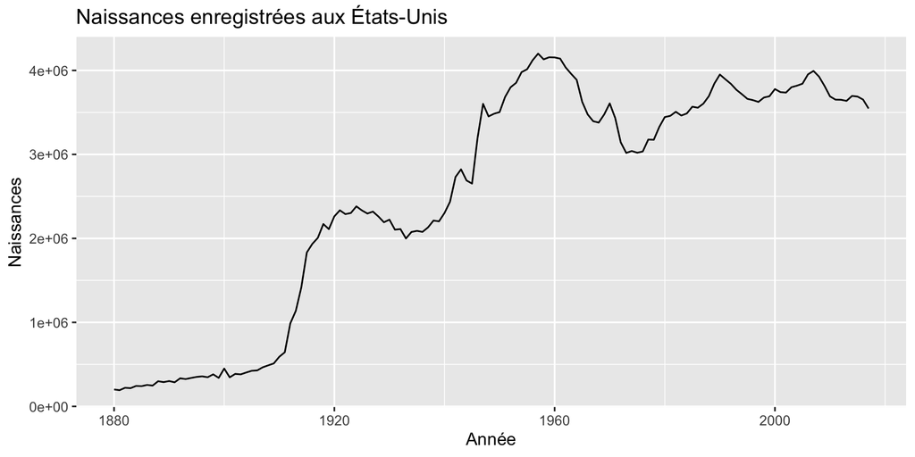

```r
naissances <- bebes |> summarise(n = sum(n), .by = year)
ggplot(naissances, aes(year, n)) +
  geom_line() +
  labs(x = "Année", y = "Naissances", title = "Naissances enregistrées aux États-Unis")
```

```r
slice_max(naissances, n, n = 1)
```

```
#> # A tibble: 1 × 2
#>    year       n
#>   <dbl>   <dbl>
#> 1  1957 4200007
```

Le maximum est en **1957**, au cœur du *baby-boom*. Attention : le fichier ne contient que les prénoms donnés au moins 5 fois dans l’année, et les premières années sont mal enregistrées. Ce sont des naissances « enregistrées », pas toutes les naissances.

## 2. Par année et par sexe

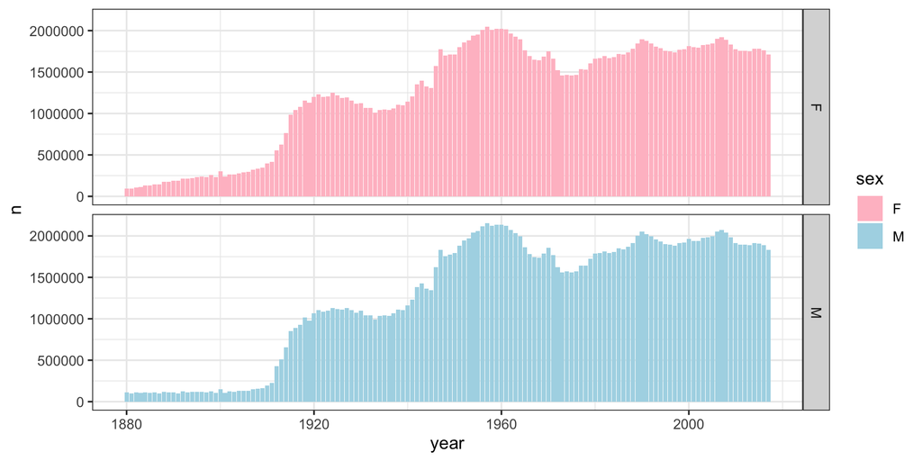

```r
bebes |>
  summarise(n = sum(n), .by = c(year, sex)) |>
  ggplot(aes(year, n, fill = sex)) +
  geom_col() +
  facet_grid(sex ~ .) +
  scale_fill_manual(values = c(F = "pink", M = "lightblue")) +
  theme_bw()
```

## 3. Par décennie

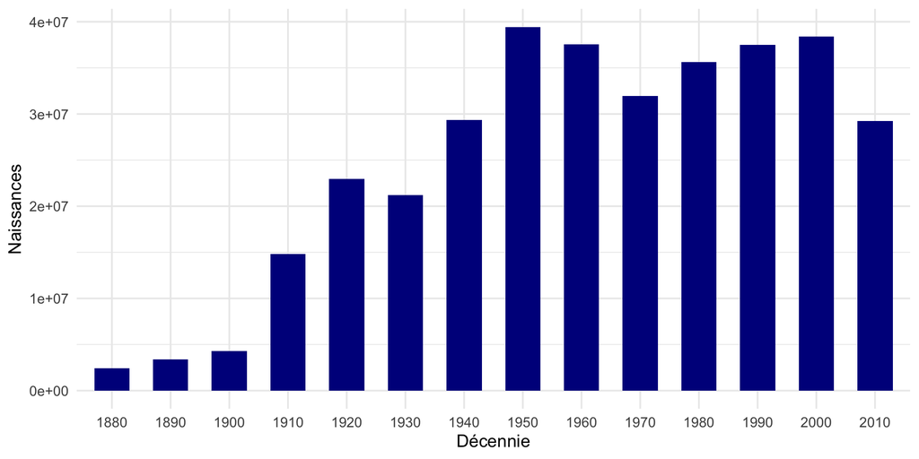

```r
bebes |>
  mutate(decennie = year %/% 10 * 10) |>
  summarise(n = sum(n), .by = decennie) |>
  ggplot(aes(factor(decennie), n)) +
  geom_col(fill = "darkblue", width = 0.6) +
  labs(x = "Décennie", y = "Naissances") +
  theme_minimal()
```

`factor(decennie)` donne une barre par décennie avec son étiquette. La dernière décennie (2010) ne contient que 8 années : sa barre est forcément plus basse. Un graphique honnête le signalerait.

## 4. Le top 10 des garçons en 2017

```r
top <- bebes |>
  filter(sex == "M", year == 2017) |>
  slice_max(n, n = 10) |>
  pull(name)
top
```

```
#>  [1] "Liam"     "Noah"     "William"  "James"    "Logan"    "Benjamin"
#>  [7] "Mason"    "Elijah"   "Oliver"   "Jacob"
```

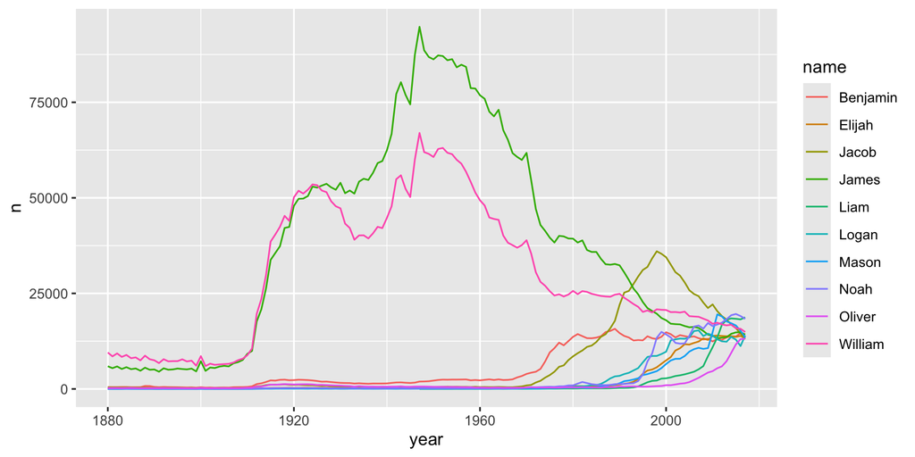

```r
bebes |>
  filter(sex == "M", name %in% top) |>
  ggplot(aes(year, n, color = name)) +
  geom_line()
```

`sex == "M"` est nécessaire **deux fois** : certains prénoms (`Logan`, `Elijah`…) sont aussi donnés à des filles, et leurs courbes se mélangeraient.

## 5. Les notes en format long

```
#> Warning: Removed 1 row containing non-finite outside the scale range
#> (`stat_boxplot()`).
```

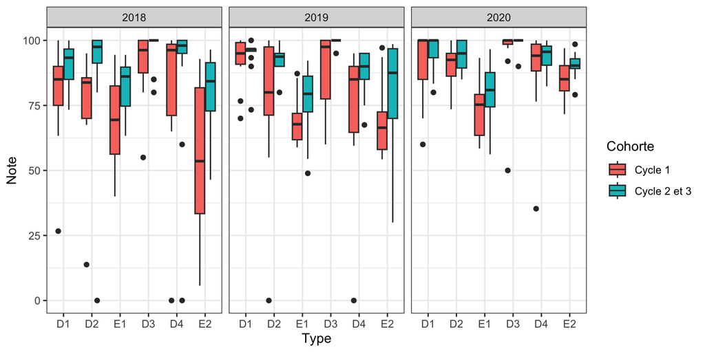

```r
notes_long <- notes |>
  pivot_longer(D1:E2, names_to = "Type", values_to = "Note") |>
  mutate(Type = fct_inorder(Type)) |>          # ordre des colonnes = ordre du trimestre
  left_join(sexes, by = "ID_etu")

ggplot(notes_long, aes(x = Type, y = Note, fill = Cohorte)) +
  geom_boxplot() +
  facet_wrap(~ Annee) +
  theme_bw()
```

Le *warning* `Removed 1 row` correspond à la note `D2` manquante. Les examens (`E1`, `E2`) ont des notes plus basses et plus dispersées que les devoirs.

## 6. Par année et par sexe

```
#> Warning: Removed 1 row containing non-finite outside the scale range
#> (`stat_boxplot()`).
```

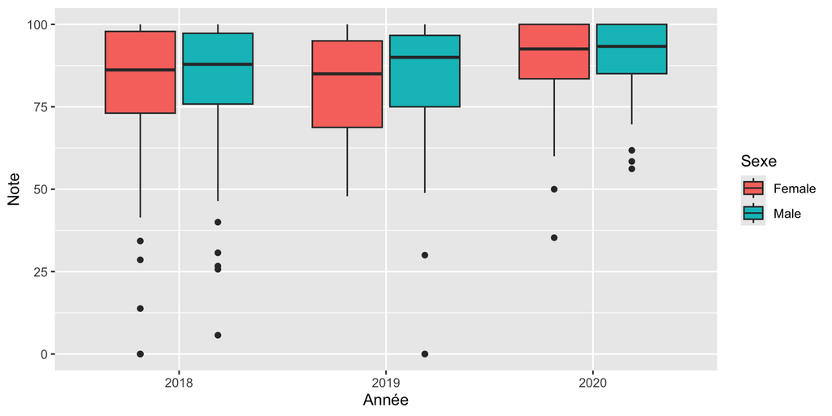

```r
ggplot(notes_long, aes(x = factor(Annee), y = Note, fill = Sex)) +
  geom_boxplot() +
  labs(x = "Année", fill = "Sexe")
```

## 7. Les positions

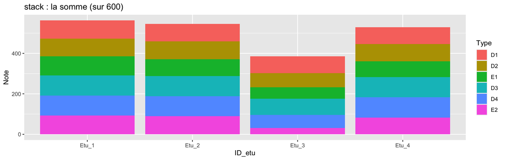

```r
quatre <- notes_long |> filter(ID_etu %in% paste0("Etu_", 1:4))
g <- ggplot(quatre, aes(x = ID_etu, y = Note, fill = Type))
g + geom_col(position = "stack") + ggtitle("stack : la somme (sur 600)")
```

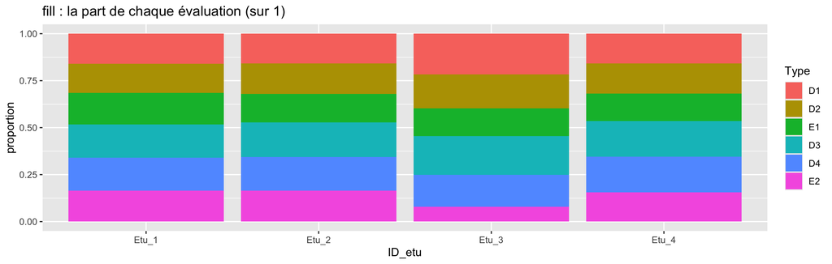

```r
g + geom_col(position = "fill") + ggtitle("fill : la part de chaque évaluation (sur 1)") + labs(y = "proportion")
```

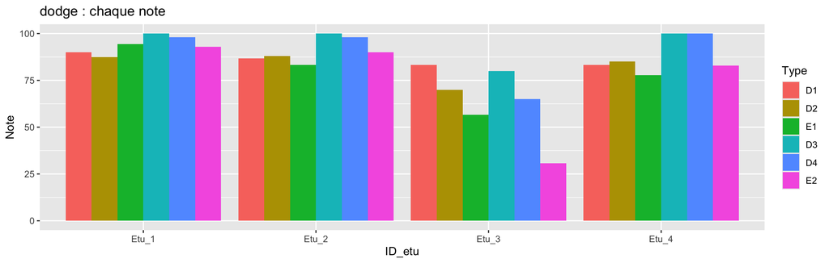

```r
g + geom_col(position = "dodge") + ggtitle("dodge : chaque note")
```

Avec `"fill"`, toutes les barres valent 1 : on compare des **parts**, plus des notes. Renommez l’axe y, sinon il annonce encore « Note ».

# Et si… ?

## 1. Sans `color = name`

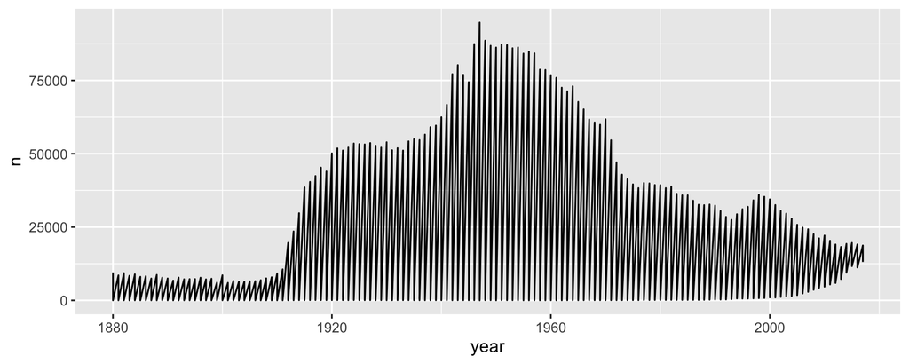

```r
bebes |>
  filter(sex == "M", name %in% top) |>
  ggplot(aes(year, n)) +
  geom_line()
```

`geom_line()` relie **toutes** les lignes du tableau dans l’ordre des x : chaque année, la ligne monte et descend entre les 10 prénoms. Aucun message. `color = name` (ou `group = name`) indique quelles lignes forment **une même courbe**.

## 2. Sans `summarise()`

```r
ggplot(bebes, aes(year, n)) + geom_line()
```

Le graphique (long à afficher : 1.9 million de lignes) est une bande noire : pour chaque année, la ligne parcourt tous les prénoms. `ggplot2` ne résume pas pour vous avec `geom_line()` : la somme se calcule **avant**.

## 3. `limits` ou `coord_cartesian()`

```
#> Warning: Removed 22 rows containing non-finite outside the scale range
#> (`stat_boxplot()`).
```

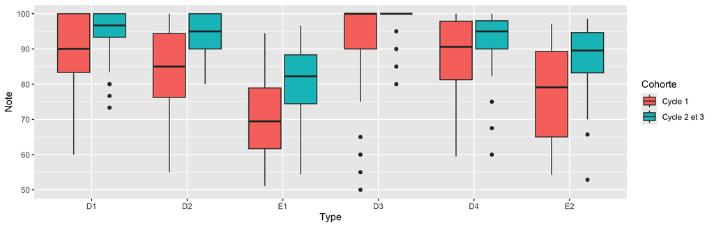

```r
ggplot(notes_long, aes(Type, Note, fill = Cohorte)) +
  geom_boxplot() +
  scale_y_continuous(limits = c(50, 100))
```

```r
notes_long |>
  summarise(mediane = median(Note, na.rm = TRUE),
            mediane_sup50 = median(Note[Note >= 50], na.rm = TRUE), .by = Type)
```

```
#> # A tibble: 6 × 3
#>   Type  mediane mediane_sup50
#>   <fct>   <dbl>         <dbl>
#> 1 D1       93.3          93.3
#> 2 D2       90            90
#> 3 E1       75.6          75.6
#> 4 D3      100           100
#> 5 D4       94.1          95
#> 6 E2       82.9          85.4
```

`limits` retire les 21 notes sous 50 (et le `NA`) **avant** le calcul : la médiane de `E2`, par exemple, passe de 82.86 à 85.39. Le *warning* est le seul indice. `coord_cartesian(ylim = c(50, 100))` zoome sans rien retirer : les boxplots restent justes, et les points sous 50 sortent simplement du cadre.

## 4. `Annee` numérique

```
#> Warning: Orientation is not uniquely specified when both the x and y aesthetics are
#> continuous. Picking default orientation 'x'.
#> Warning: Removed 1 row containing non-finite outside the scale range
#> (`stat_boxplot()`).
```

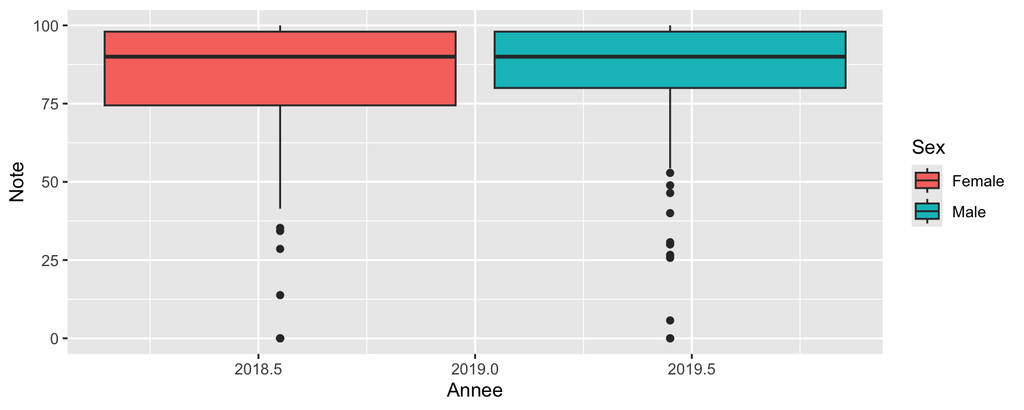

```r
ggplot(notes_long, aes(x = Annee, y = Note, fill = Sex)) +
  geom_boxplot()
```

`Annee` est un **nombre** : l’axe x est continu, et `ggplot2` ne sait pas qu’il faut une boîte par année. Il fait une boîte **par sexe**, sur les trois années mélangées, placée vers 2019. Le seul indice est un *warning* qui ne parle pas du problème (`Orientation is not uniquely specified when both the x and y aesthetics are continuous`) : il faut **regarder** l’axe x. `factor(Annee)` transforme l’année en **catégorie**.

## 5. L’ordre oublié

```
#> Warning: Removed 1 row containing non-finite outside the scale range
#> (`stat_boxplot()`).
```

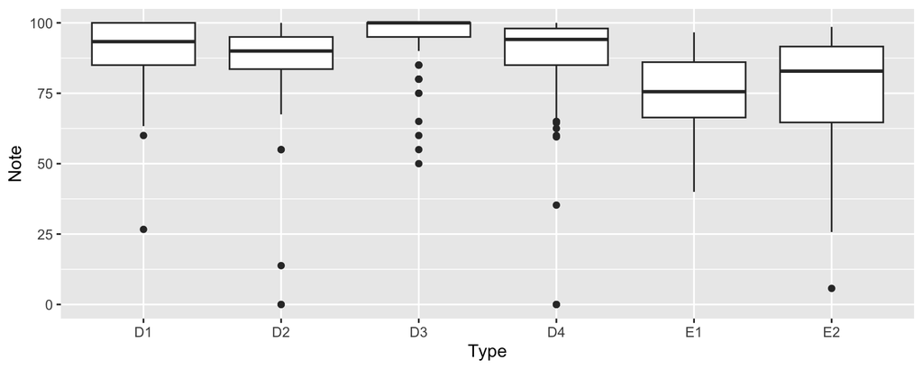

```r
notes |>
  pivot_longer(D1:E2, names_to = "Type", values_to = "Note") |>
  ggplot(aes(Type, Note)) +
  geom_boxplot()
```

Sans facteur, `ggplot2` trie le texte **par ordre alphabétique** : D1, D2, D3, D4, E1, E2. Les examens sont regroupés à la fin : un lecteur croirait que les notes baissent en fin de trimestre, alors que c’est le **type** d’évaluation qui compte. `fct_inorder()` (ordre des colonnes) ou `factor(Type, levels = c("D1", "D2", "E1", "D3", "D4", "E2"))` rétablissent l’ordre réel.